# The Elo method in chess

Isabella Flego

```r
library(dplyr)
library(tidyverse)
data <- read.csv("data.csv")
head(data)
```

```
##   White Black Score
## 1    73  1246   0.5
## 2    73  5097   0.5
## 3    73  5104   0.5
## 4    73  7321   1.0
## 5    73  7375   0.5
## 6    88  1033   0.5
```

### domanda 1

```r
partite_tot = nrow(data)
vittorie_bianco = sum(data$Score == 1)
vittorie_nero = sum(data$Score == 0)
pareggi = sum(data$Score == 0.5)

if(vittorie_bianco > vittorie_nero) {
  cat ("L'analisi dei risultati mostra un vantaggio per chi muove per primo: infatti i giocatori con i pezzi bianchi hanno registrato " ,vittorie_bianco, " vittorie, contro le " ,vittorie_nero, " di chi ha giocato con il nero.")
} else {
  cat ("L'analisi dei risultati non mostra un vantaggio per chi muove per primo: i giocatori con i pezzi bianchi hanno registrato " ,vittorie_bianco, " vittorie, contro le " ,vittorie_nero, " di chi ha giocato con il nero.")
}
```

```
## L'analisi dei risultati mostra un vantaggio per chi muove per primo: infatti i giocatori con i pezzi bianchi hanno registrato  21163  vittorie, contro le  15224  di chi ha giocato con il nero.
```

### domanda 2

```r
classifica <- data |>
  pivot_longer(
    cols = c("White", "Black"),
    names_to = "WhiteBlack",
    values_to ="Giocatore"
  ) |>
  mutate(
    Punti = case_when(
      (Score == 1 & WhiteBlack == "White") ~ 1,
      (Score == 1 & WhiteBlack == "Black") ~ 0,
      (Score == 0 & WhiteBlack == "White") ~ 0,
      (Score == 0 & WhiteBlack == "Black") ~ 1,
      TRUE ~ 0.5
    )
  ) |>
  group_by(Giocatore) |>
  summarize (
    Punti = sum(Punti),
    NumPartite = n()
  )

classifica
```

```
## # A tibble: 7,301 × 3
##    Giocatore Punti NumPartite
##        <int> <dbl>      <int>
##  1         1  31           52
##  2         2   0.5          1
##  3         3   3            8
##  4         4  23.5         46
##  5         5   4           13
##  6         6   7           13
##  7         7  14           33
##  8         8   0            1
##  9         9   0.5          3
## 10        10   3           14
## # ℹ 7,291 more rows
```

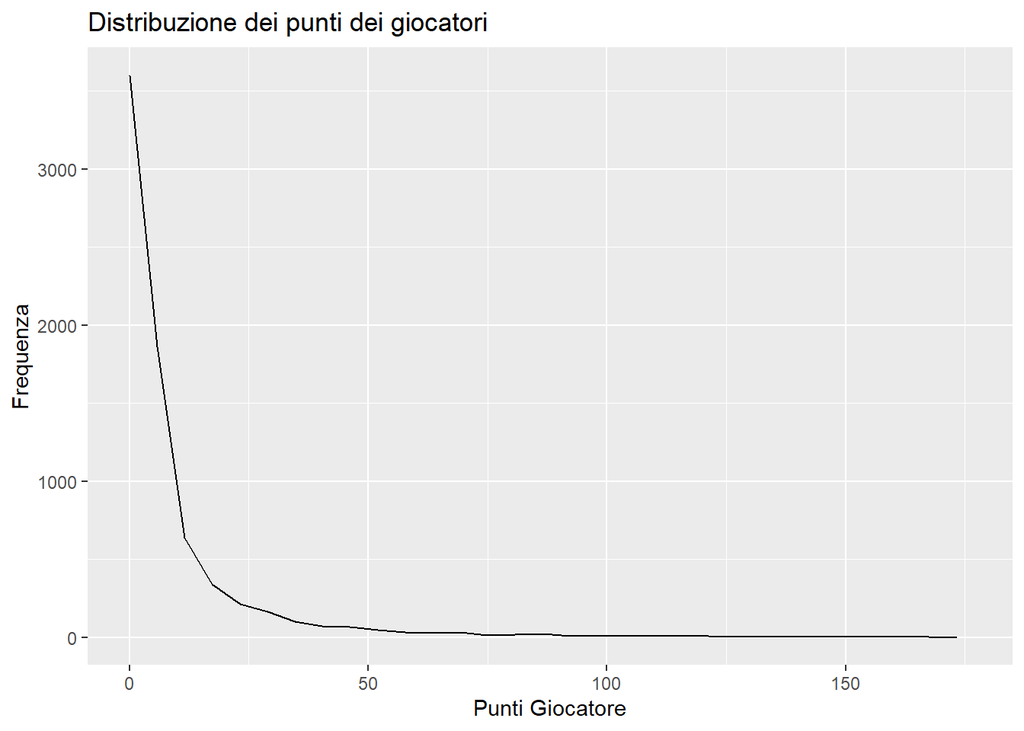

```r
distribuzione_punteggi <- ggplot(data = classifica) +
  geom_freqpoly(mapping = aes(x = Punti), na.rm = TRUE) +
  scale_x_continuous(limits = c(0, NA)) +
  labs(
    title = "Distribuzione dei punti dei giocatori",
    x = "Punti Giocatore",
    y = "Frequenza"
  )

distribuzione_punteggi
```

Il grafico mostra una distribuzione dei punti totali non lineare, con un picco in corrispondenza dello zero e con una coda verso i valori più alti: questo significa che la maggioranza dei giocatori ha un punteggio basso (dato dal numero basso di parite giocate o vinte) e che solamente poche persone riescono a ottenere punteggi elevati.

### domanda 3

I giocatori inizialmente hanno punteggio pari a 0. Nel momento in cui i giocatori $i$ e $j$ si affrontano, i loro punteggi si aggiornano secondo la regola:

$$\begin{array}{lll}
r_{i} & \leftarrow & r_i + \kappa (s_{i,j} - \mu_{i,j})
\\
r_j & \leftarrow & r_j + \kappa (s_{j,i} - \mu_{j,i})
\end{array}$$
Da questa regola, è possibile trovare la formula della variazione $\Delta r$ per ogni giocatore:
$$\begin{array}{lll}
\Delta r_{i} & = & \kappa (s_{i,j} - \mu_{i,j}) \\
\Delta r_{j} & = & \kappa (s_{j,i} - \mu_{j,i}) \\
\end{array}$$

### domanda 4

```r
calcola_elo <- function(data, C = 400, k = 25) {

  #creo vettore con id giocatori e punteggio iniziale di elo = 0
  giocatori <- unique(c(data$White, data$Black))
  elo <- setNames(rep(0, length(giocatori)), giocatori)

  # Aggiorno il rating partita per partita
  for (i in 1:nrow(data)) {

    bianco <- as.character(data$White[i])
    nero <- as.character(data$Black[i])

    # Punteggio effettivo del Bianco
    s_bianco <- data$Score[i]

    # Punteggio atteso del Bianco
    atteso_bianco <- 1 / (1 + 10^((elo[nero] - elo[bianco]) / C))

    # Variazione del rating
    delta <- k * (s_bianco - atteso_bianco)

    # Aggiorno i rating dei due giocatori
    elo[bianco] <- elo[bianco] + delta
    elo[nero] <- elo[nero] - delta
  }

  return(elo)
}

classificaElo <- calcola_elo(data)

classificaElo <- tibble(
  Giocatore = as.numeric(names(classificaElo)),
  PuntiElo = as.numeric(classificaElo)
  ) |>
  arrange(Giocatore)

classificaElo
```

```
## # A tibble: 7,301 × 2
##    Giocatore PuntiElo
##        <dbl>    <dbl>
##  1         1   102.
##  2         2    -1.81
##  3         3   -20.0
##  4         4   -10.2
##  5         5   -43.5
##  6         6    12.6
##  7         7   -12.7
##  8         8   -13.0
##  9         9   -21.1
## 10        10   -86.0
## # ℹ 7,291 more rows
```

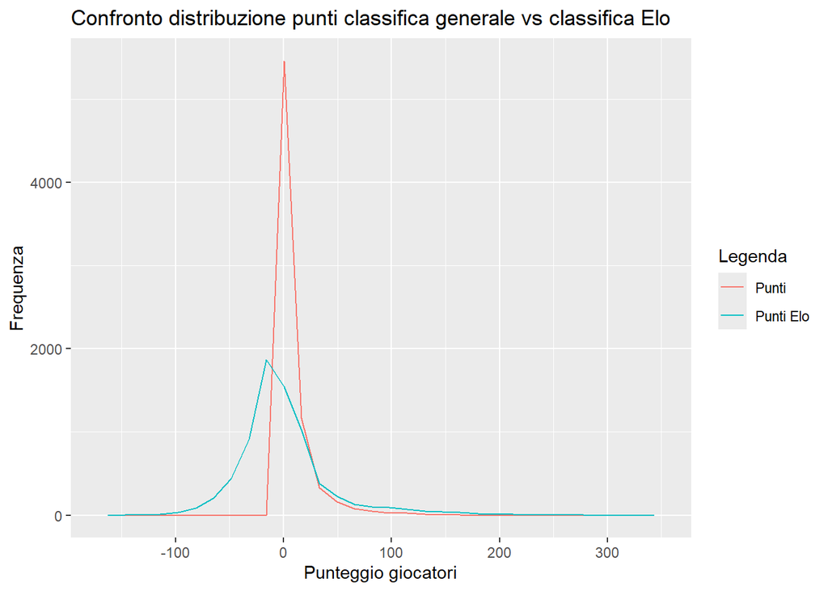

```r
ggplot() +
  geom_freqpoly(data = classifica, aes(x = Punti, color = "Punti")) +
  geom_freqpoly(data = classificaElo, aes(x = PuntiElo, color = "Punti Elo")) +
  labs(
    title = "Confronto distribuzione punti classifica generale vs classifica Elo",
    x = "Punteggio giocatori",
    y = "Frequenza",
    color = "Legenda"
  )
```

La distribuzione dei punti Elo ammette anche valori negativi, a differenza della classifica generale che prevede solo punteggi positivi o nulli. Proprio per questa modalità di assegnamento di punti si può notare che il picco massimo dei punti generali è più elevata perchè non vengono mai sottratti al giocatore, anche in caso di perdita. Nonostante questo entrambe le curve mostrano un andamento simile, con frequenza massima concentrata attorno allo zero e dimunuzione con l’aumentare del punteggio.

```r
somma = sum(classificaElo$PuntiElo)
cat("La proprietà per cui la somma dei punteggi Elo sia uguale a zero è verificata: il valore ottenuto è ", somma, ", un numero estremamente piccolo, probabilmente dovuto a errori di approssimazione.")
```

```
## La proprietà per cui la somma dei punteggi Elo sia uguale a zero è verificata: il valore ottenuto è  9.476309e-13 , un numero estremamente piccolo, probabilmente dovuto a errori di approssimazione.
```

### domanda 5

```r
confronto <- full_join(classificaElo, classifica ,by="Giocatore")
confronto
```

```
## # A tibble: 7,301 × 4
##    Giocatore PuntiElo Punti NumPartite
##        <dbl>    <dbl> <dbl>      <int>
##  1         1   102.    31           52
##  2         2    -1.81   0.5          1
##  3         3   -20.0    3            8
##  4         4   -10.2   23.5         46
##  5         5   -43.5    4           13
##  6         6    12.6    7           13
##  7         7   -12.7   14           33
##  8         8   -13.0    0            1
##  9         9   -21.1    0.5          3
## 10        10   -86.0    3           14
## # ℹ 7,291 more rows
```

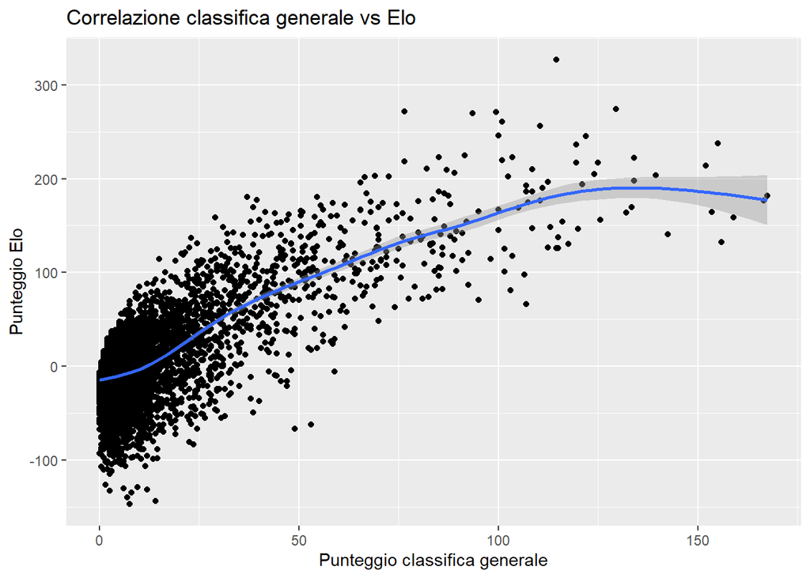

```r
correlazione <- ggplot(data = confronto, mapping = aes(x = Punti, y = PuntiElo)) +
  geom_point() +
  labs(
    x = "Punteggio classifica generale",
    y = "Punteggio Elo",
    title = "Correlazione classifica generale vs Elo") +
  geom_smooth()

correlazione
```

Tra la classifica generale e quella Elo esiste una correlazione positiva ma non lineare: tendenzialmente, all’aumentare dei punti generali crescono anche i punti Elo. Tuttavia, i vertici delle due graduatorie non coincidono: il giocatore con il punteggio Elo più alto in assoluto, infatti, registra un valore nettamente inferiore rispetto a quello raggiunto dai primi della classifica generale, e viceversa.

### domanda 6

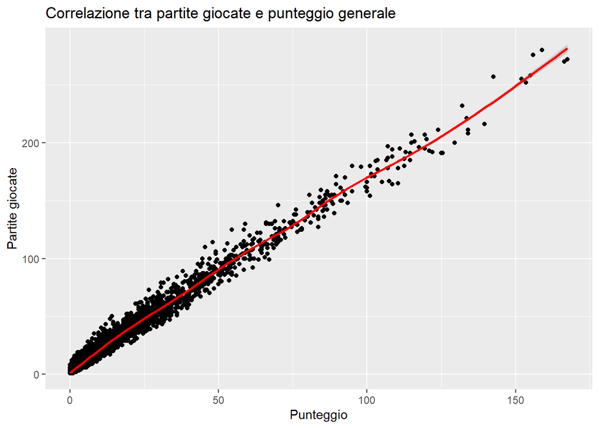

```r
partite_punteggio <- ggplot(data = confronto, mapping = aes(x = Punti, y = NumPartite)) +
  geom_point() +
  labs(
    x = "Punteggio",
    y = "Partite giocate",
    title = "Correlazione tra partite giocate e punteggio generale") +
  geom_smooth(color="red")

partite_punteggioElo <- ggplot(data = confronto, mapping = aes(x = PuntiElo, y = NumPartite)) +
  geom_point() +
  labs(x = "Punteggio Elo",
       y = "Partite giocate",
       title = "Correlazione tra partite giocate e punteggio Elo") +
  geom_smooth(color="blue")

partite_punteggio
```

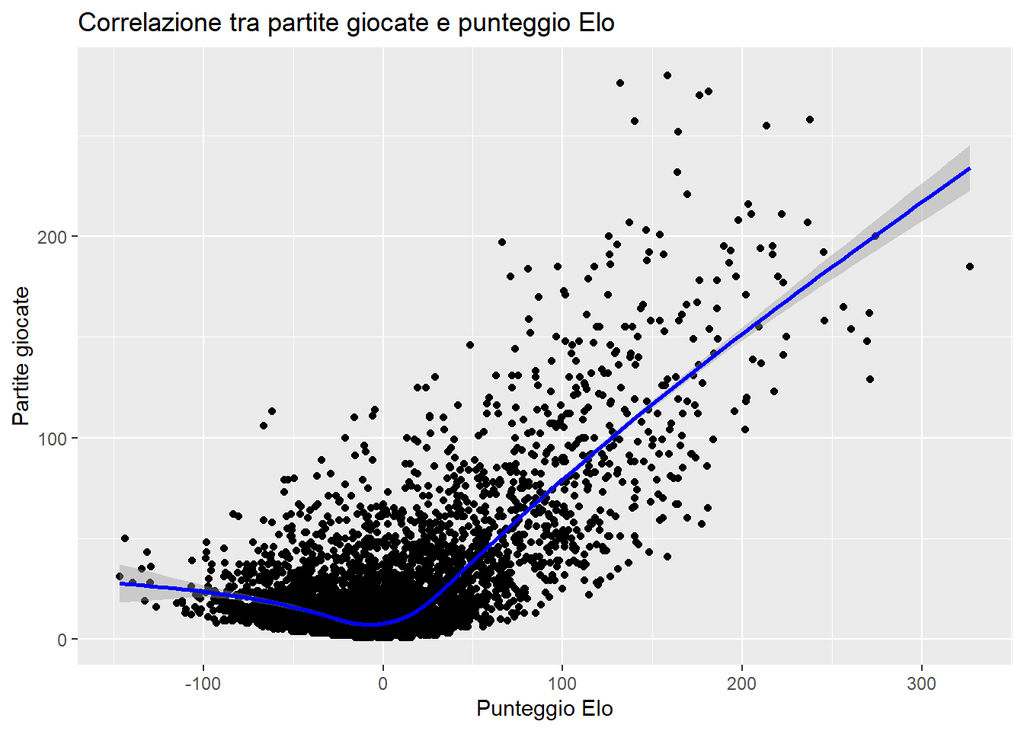

```r
partite_punteggioElo
```

Tra il numero di partite giocate e il punteggio in classifica generle esiste una correlazione lineare positiva tra le partite giocate e il punteggio generale: all’aumentare delle partite giocate, il punteggio cresce in modo diretto e proporzionale.

Invece tra le partite giocate e il punteggio Elo la correlzione non è lineare: per i punteggi negativi o vicini allo zero non c’è una relzione precisa, mentre per i punteggi positivi si evidenzia una correlazione positiva, in cui all’aumentare delle partite cresce anche il punteggio Elo.